# Week 14: Big Regressions

PS 818 - Statistical Models

Anton Strezhnev

strezhnev@wisc.edu

University of Wisconsin-Madison

December 1, 2025

$$\require{cancel}
\DeclareMathOperator*{\argmin}{arg\,min}$$

$$\DeclareMathOperator*{\argmax}{arg\,max}$$

# This Week

$$\DeclareMathOperator*{\argmax}{arg\,max}$$

# This Week

- Analyses with **big data**
  - Data that cannot fit entirely into computer **memory** (RAM)
- General principles for handling large data files
- **Stochastic** optimization methods
  - Stochastic gradient descent for maximum likelihood models
- **Sufficient statistics** computed out-of-memory
  - Tricks for regressions with many **discrete regressors**

# Review: Generalized Linear Models

- Generalized linear models (GLMs) have three components:
  1. A parametric distribution on $Y_i|X_i$ (“stochastic component”)
  2. A linear predictor: $\eta_i = X_i^{\prime}\beta = \beta_0 + \beta_1X_{i1} + \beta_2X_{i2} + \dotsc \beta_kX_{ik}$ (“systematic component”)
  3. A link function $g()$ applied to the CEF $E[Y_i|X_i]$ that yields the linear predictor

     $$g(E[Y_i | X_i]) = \eta_i$$
  - Alternatively, we can write the CEF in terms of the “inverse-link” $g^{-1}()$ applied to the linear predictor

    $$E[Y_i | X_i] = g^{-1}(\eta_i)$$

# Review: Logistic regression

- The “logit” or “logistic” GLM models the **log-odds** of a binary outcome as a function of the linear predictor $X_i^{\prime}\beta$

  $$Y_i \underset{\text{i.i.d}}{\sim} \text{Bernoulli}(\pi_i)$$

  $$E[Y_i | X_i] = Pr(Y_i = 1 | X_i) = \pi_i$$

  $$\log\bigg(\frac{\pi_i}{1-\pi_i}\bigg) = X_i^{\prime}\beta$$
- Alternatively, this is written in terms of the “inverse-link” function (the logistic function) that relates $\pi_i$ to $g^{-1}(X_i^{\prime}\beta)$

  $$\pi_i = \frac{\exp(X_i^{\prime}\beta)}{1 + \exp(X_i^{\prime}\beta)} = \frac{1}{1 + \exp(-X_i^{\prime}\beta)}$$

# Review: Logistic regression

- The logistic function maps inputs on $\mathbb{R}$ to $(0, 1)$

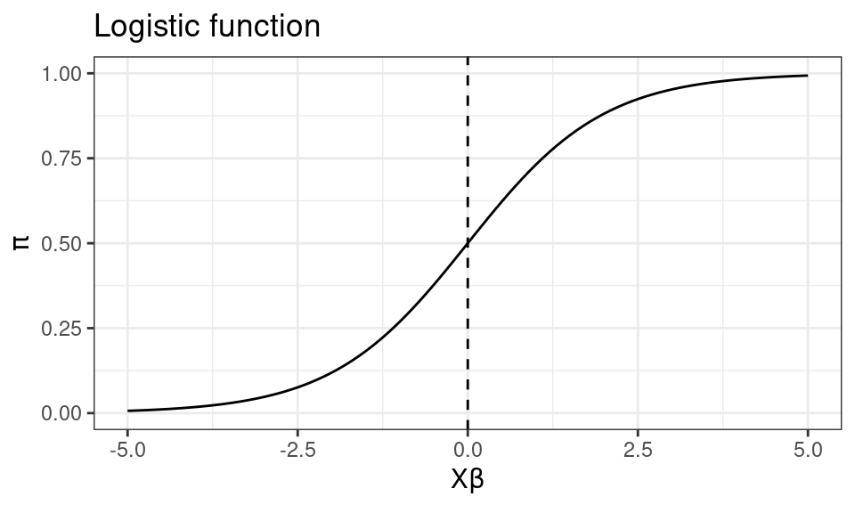

# Review: Logistic regression

- Recall the log-likelihood for the logistic regression

$$\log f(\mathbf{y} | \beta, \mathbf{X}) = \sum_{i=1}^{n} \left[ y_i (X_i^{\prime} \beta) - \log(1 + \exp(X_i^{\prime} \beta)) \right]$$

- We can use the chain rule to get the gradient

$$\nabla \log f(\mathbf{y} | \beta, \mathbf{X}) = \sum_{i=1}^{n} \left[ y_i X_i - \frac{\exp(X_i^\prime\beta)}{1 + \exp(X_i^\prime\beta)}X_i \right]$$

- Using the definition of the “predicted probabilities” $\pi_i$

$$\nabla \log f(\mathbf{y} | \beta, \mathbf{X}) = \sum_{i=1}^{n} (y_i - \pi_i)X_i$$

# Review: Newton-Raphson

- We obtain an estimate of $\beta$, $\hat{\beta}$ using maximum likelihood.
- Our MLE estimator is:

  $$\hat{\beta} = \argmax_\beta \ \log f(\mathbf{y} | \beta, \mathbf{X})$$
- Recall our score function is the gradient of the log-likelihood

  $$S(\beta) = \nabla \log f(\mathbf{y} | \beta, \mathbf{X}) = \begin{bmatrix} \frac{\partial}{\partial \beta_0} \log f(\mathbf{y} | \beta, \mathbf{X}) \\
  \frac{\partial}{\partial \beta_1} \log f(\mathbf{y} | \beta, \mathbf{X}) \\
  \vdots \\
  \frac{\partial}{\partial \beta_k} \log f(\mathbf{y} | \beta, \mathbf{X}) \end{bmatrix}$$
- The likelihood is convex, so finding the maximum equates to solving for the value of $\beta$ that sets $S(\beta) = 0$
  - A common numerical method is **Newton-Raphson**

# Review: Newton-Raphson

- Given some initial starting values $\hat{\beta}^{(0)}$, our update steps $\hat{\beta}^{(t+1)}$ proceed deterministically until convergence using previous values $\hat{\beta}^{(t)}$

  $$\hat{\beta}^{(t+1)} = \hat{\beta}^{(t)} + \bigg(-\mathbf{H}^{-1}(\hat{\beta}^{(t)})\bigg) \nabla \log f(\mathbf{y} | \hat{\beta}^{(t)}, \mathbf{X})$$
- What is this information?
  - The **gradient** of the log-likelihood: $\nabla \log f(\mathbf{y} | \hat{\beta}^{(t)}, \mathbf{X})$
  - The (negative) inverse **hessian** (step size)
- Why is this hard? Why don’t we do this for “machine learning”
  - Because inverting large matrices is computationally costly

# Gradient Ascent

- Instead of changing the “step size” in a data-dependent manner, what if we just fixed it
- The **gradient ascent** algorithm would instead use update steps

  $$\hat{\beta}^{(t+1)} = \hat{\beta}^{(t)} + \gamma_{t}\nabla \log f(\mathbf{y} | \hat{\beta}^{(t)}, \mathbf{X})$$
- We refer to $\gamma = \{\gamma_0, \gamma_1, \gamma_2, \dotsc \} > 0$ as our “learning rate schedule”
  - Too big, we overshoot
  - Too small, we don’t explore the likelihood
- Often just pick a constant rate that doesn’t depend on the iteration $\gamma_0 = \gamma_1 = \gamma_2 = \dotsc$
  - Alternatively, set some degree of **decay** (e.g. exponential decay $\gamma_{t} = \gamma_0 \times e^{-kt}$)

# Large datasets with `data.table`

- We’re going to look at data management with the R package `data.table`

```r
library(data.table)
```

- Why use `data.table` instead of the standard `read_csv` or `read.csv`?
  - It handles **very large** datasets much better!
  - Faster file-IO, “chunking” of datasets that can’t fit into memory, operations directly on datasets (avoid copying and duplicating memory), etc…
- If you genuinely have an **extremely large** dataset, you’ll probably be working with a **relational database**
  - Typical interaction via the **SQL** language.
  - If you know `tidy` verbs, you can learn SQL easily. Also similar motivation for `data.table` syntax
  - Outside the scope of this class at this moment (but core principles remain).

# Example: NC Voter File

- Let’s do a simple predictive model:
  - What is the probability that someone voted in the **2024 General Election** given known information (age, party, gender, race) as well as their prior voting history.
- We’ll work with the most current version of the North Carolina Voter File and the Voter History file (since it’s free to download)
  - Millions of records!
  - Unfortunately…two separate databases that need to be merged.
  - One is a **6 GB** text file, the other is **4 GB** text file

# Example: NC Voter File

- Let’s load the data into R with `fread()`

```r
ncvhis <- fread("data/ncvhis_Statewide.txt") # Reads in the whole voter history file
ncvhis <- ncvhis[,c("ncid","election_lbl", "voting_method")] # We just want the ID of the voter and which elections they voted in
ncvhis <- ncvhis[!duplicated(ncvhis, by = c("ncid", "election_lbl"))] # Get rid of duplicates
gc() # "Garbage collect" to reallocate memory.
```

```
           used (Mb) gc trigger (Mb) max used (Mb)
Ncells 9.11e+06  487   1.81e+07  967 9.13e+06  488
Vcells 1.29e+08  987   6.53e+08 4984 8.08e+08 6167
```

# Example: NC Voter File

- We want to make the dataset *wide* so that we can merge the elections where the voter voted with the actual voter file.
  - Each column should be an election - the content should be an indicator for “voted/didn’t vote”

```r
ncvhis_wide <- dcast(ncvhis, ncid ~ election_lbl, value.var = "voting_method") # Equivalent of pivot.wider
rm(ncvhis) # Get rid of the old data.table
gc() # Garbage collect to free up memory!
```

```
           used (Mb) gc trigger (Mb) max used (Mb)
Ncells 9.13e+06  488   1.81e+07  967 9.66e+06  516
Vcells 3.05e+08 2325   8.09e+08 6171 8.08e+08 6167
```

```r
head(ncvhis_wide) # What does the new dataset look like?
```

```
Key: <ncid>
       ncid 01/29/2019             03/03/2020             03/05/2024 03/07/2023
     <char>     <char>                 <char>                 <char>     <char>
1: AA100000       <NA> ELECTION DAY IN-PERSON EARLY VOTING IN-PERSON       <NA>
2: AA100006       <NA>                   <NA>                   <NA>       <NA>
3: AA100007       <NA>       ABSENTEE BY MAIL       ABSENTEE BY MAIL       <NA>
4: AA100008       <NA>                   <NA>                   <NA>       <NA>
5: AA100009       <NA>                   <NA> ELECTION DAY IN-PERSON       <NA>
6:  AA10001       <NA>                   <NA>                   <NA>       <NA>
               03/15/2016 04/30/2019             05/08/2018 05/14/2019
                   <char>     <char>                 <char>     <char>
1:                   <NA>       <NA>                   <NA>       <NA>
2: ELECTION DAY IN-PERSON       <NA>                   <NA>       <NA>
3:                   <NA>       <NA>                   <NA>       <NA>
4:                   <NA>       <NA>                   <NA>       <NA>
```

[output cut: 58 more lines]

# Example: NC Voter File

- Let’s grab the last five general elections

```r
ncvhis_wide <- ncvhis_wide[,c("ncid","11/05/2024", "11/08/2022", "11/03/2020", "11/06/2018", "11/08/2016")]
ncvhis_wide[,`11/05/2024` := fifelse(!is.na(`11/05/2024`), 1, 0)] # Modify the columns *directly*
ncvhis_wide[,`11/08/2022` := fifelse(!is.na(`11/08/2022`), 1, 0)]
ncvhis_wide[,`11/03/2020` := fifelse(!is.na(`11/03/2020`), 1, 0)]
ncvhis_wide[,`11/06/2018` := fifelse(!is.na(`11/06/2018`), 1, 0)]
ncvhis_wide[,`11/08/2016` := fifelse(!is.na(`11/08/2016`), 1, 0)]
setnames(ncvhis_wide, old = c("11/05/2024", "11/08/2022", "11/03/2020", "11/06/2018", "11/08/2016"),
         new = c("voted2024", "voted2022", "voted2020", "voted2018", "voted2016"))
```

# Example: NC Voter File

- Now we need to merge it to the voter file. Let’s load up the voter file!

```r
ncvoter <- fread("data/ncvoter_Statewide.txt")
ncvoter <- ncvoter[voter_status_desc != "REMOVED"&voter_status_desc != "DENIED"]
```

- We’ll need to now merge based on `ncid`

# Example: NC Voter File

```r
ncvoter <- merge(ncvoter, ncvhis_wide, by="ncid", all.x=T, all.y=F)
rm(ncvhis_wide) # Get rid of the old file!
ncvoter <- ncvoter[,c('ncid','voted2024', 'voted2020','voted2016','voted2022','voted2018','birth_year','gender_code','ethnic_code', 'party_cd', 'race_code')]
gc()
```

```
           used (Mb) gc trigger (Mb) max used (Mb)
Ncells 9.03e+06  482   3.10e+07 1654 2.33e+07 1243
Vcells 1.12e+08  852   9.41e+08 7176 1.18e+09 8969
```

- Need to make any voter entries that didn’t match into **non-voters**

```r
ncvoter[is.na(voted2024), voted2024 := 0] # Again, modifying the columns *directly*
ncvoter[is.na(voted2022), voted2022 := 0]
ncvoter[is.na(voted2020), voted2020 := 0]
ncvoter[is.na(voted2018), voted2018 := 0]
ncvoter[is.na(voted2016), voted2016 := 0]
```

- How many voted?

```r
mean(ncvoter$voted2024)
```

```
[1] 0.742
```

# Trying to fit logistic regression

- Can we actually fit `glm()` to a dataset that takes up more than half of my laptop’s memory?
  - We can - this implementation does work - but **only just**

```r
voting_reg <- glm(voted2024 ~ voted2020 + voted2016 + voted2022 + voted2018 +
                    I(birth_year <= 1964) + I(birth_year > 1964&birth_year <= 1980) +
                    I(birth_year > 1997) + I(gender_code == "M") + I(ethnic_code == "HL") +
                    I(race_code == "W") + I(party_cd == "REP") +
                    I(party_cd == "UNA") + I(party_cd == "LIB") + I(party_cd == "GRE"), data=ncvoter, family=binomial(link="logit"))
gc()
```

```
           used (Mb) gc trigger (Mb) max used (Mb)
Ncells 1.67e+07  890   2.48e+07 1323 2.33e+07 1243
Vcells 3.82e+08 2916   1.13e+09 8611 1.18e+09 8969
```

# Trying to fit logistic regression

```r
summary(voting_reg)
```

```
Call:
glm(formula = voted2024 ~ voted2020 + voted2016 + voted2022 +
    voted2018 + I(birth_year <= 1964) + I(birth_year > 1964 &
    birth_year <= 1980) + I(birth_year > 1997) + I(gender_code ==
    "M") + I(ethnic_code == "HL") + I(race_code == "W") + I(party_cd ==
    "REP") + I(party_cd == "UNA") + I(party_cd == "LIB") + I(party_cd ==
    "GRE"), family = binomial(link = "logit"), data = ncvoter)

Coefficients:
                                              Estimate Std. Error z value
(Intercept)                                   -0.38971    0.00272 -143.06
voted2020                                      0.74684    0.00234  319.33
voted2016                                      0.41579    0.00283  146.72
voted2022                                      2.12408    0.00298  711.92
voted2018                                      0.10727    0.00308   34.80
I(birth_year <= 1964)TRUE                      0.10620    0.00281   37.79
I(birth_year > 1964 & birth_year <= 1980)TRUE  0.25228    0.00273   92.29
I(birth_year > 1997)TRUE                       0.02092    0.00266    7.87
I(gender_code == "M")TRUE                     -0.16525    0.00198  -83.43
I(ethnic_code == "HL")TRUE                    -0.04172    0.00413  -10.10
I(race_code == "W")TRUE                        0.34825    0.00217  160.67
I(party_cd == "REP")TRUE                       0.14944    0.00282   52.96
I(party_cd == "UNA")TRUE                      -0.16727    0.00240  -69.73
I(party_cd == "LIB")TRUE                      -0.32261    0.01091  -29.58
I(party_cd == "GRE")TRUE                       0.15158    0.03406    4.45
                                              Pr(>|z|)
(Intercept)                                    < 2e-16 ***
voted2020                                      < 2e-16 ***
voted2016                                      < 2e-16 ***
voted2022                                      < 2e-16 ***
voted2018                                      < 2e-16 ***
I(birth_year <= 1964)TRUE                      < 2e-16 ***
I(birth_year > 1964 & birth_year <= 1980)TRUE  < 2e-16 ***
I(birth_year > 1997)TRUE                       3.5e-15 ***
I(gender_code == "M")TRUE                      < 2e-16 ***
I(ethnic_code == "HL")TRUE                     < 2e-16 ***
I(race_code == "W")TRUE                        < 2e-16 ***
I(party_cd == "REP")TRUE                       < 2e-16 ***
I(party_cd == "UNA")TRUE                       < 2e-16 ***
I(party_cd == "LIB")TRUE                       < 2e-16 ***
I(party_cd == "GRE")TRUE                       8.6e-06 ***
---
Signif. codes:  0 '***' 0.001 '**' 0.01 '*' 0.05 '.' 0.1 ' ' 1

(Dispersion parameter for binomial family taken to be 1)

    Null deviance: 8701732  on 7619889  degrees of freedom
Residual deviance: 6490106  on 7619875  degrees of freedom
AIC: 6490136

Number of Fisher Scoring iterations: 5
```

# Sparse Matrices

- Let’s consider how large the data matrix is when I use `model.matrix` for the regression.

```r
big.design.matrix <- model.matrix(voted2024 ~ voted2020 + voted2016 + voted2022 + voted2018 + I(birth_year <= 1964) + I(birth_year > 1964&birth_year <= 1980) + I(birth_year > 1997) + I(gender_code == "M") + I(ethnic_code == "HL") + I(race_code == "W") + I(party_cd == "REP") + I(party_cd == "UNA") + I(party_cd == "LIB") + I(party_cd == "GRE"), data=ncvoter)
print(object.size(big.design.matrix), units="MB")
```

```
1337.1 Mb
```

```r
rm(big.design.matrix)
gc()
```

```
           used (Mb) gc trigger (Mb) max used (Mb)
Ncells 1.67e+07  890   2.48e+07 1323 2.33e+07 1243
Vcells 3.82e+08 2916   1.13e+09 8611 1.18e+09 8969
```

# Sparse Matrices

- A more memory-efficient way of storing things is in a **sparse** matrix.
  - Especially when most entries are **zero**. We can just store a list of all of the indices that are equal to $1$
  - Nice implementation in `MatrixModels`
  - Lots of libraries are designed around using **sparse** matrices - consider these as a solution if you are running analyses that involve matrices with lots of zeroes.

```r
library(MatrixModels)
sparse.design.matrix <- model.Matrix(voted2024 ~ voted2020 + voted2016 + voted2022 + voted2018 + I(birth_year <= 1964) + I(birth_year > 1964&birth_year <= 1980) + I(birth_year > 1997) + I(gender_code == "M") + I(ethnic_code == "HL") + I(race_code == "W") + I(party_cd == "REP") + I(party_cd == "UNA") + I(party_cd == "LIB") + I(party_cd == "GRE"), data=ncvoter, sparse=T)
print(object.size(sparse.design.matrix), units="MB")
```

```
953.4 Mb
```

```r
rm(sparse.design.matrix)
gc()
```

```
           used (Mb) gc trigger (Mb) max used (Mb)
Ncells 1.79e+07  956   2.98e+07 1590 2.33e+07 1243
Vcells 3.84e+08 2932   1.13e+09 8611 1.18e+09 8969
```

# Stochastic Gradient Descent

- Let’s return to our **algorithm** for constructing estimates of $\beta$
  - In conventional (‘batch’) gradient ascent, we used the **entire** dataset to compute the gradient.
  - But what if we can’t load the entire dataset into memory!
- **Solution**: “Online” learning
  - What if we computed the gradient updates using a randomly selected **single observation**?

$$\hat{\beta}^{(t+1)} = \hat{\beta}^{(t)} + \gamma_{t+1} \nabla \log f(y_{t+1} | \hat{\beta}^{(t)}, X_{t+1})$$

- **Robbins and Munro (1951)** showed that this will converge as the number of iterations goes to infinity subject to conditions on the learning rate schedule
  - $\sum_{t=1}^{\infty} \gamma_{t} = \infty$, $\sum_{t=1}^{\infty} \gamma_{t}^2 < \infty$
- Can improve performance further if we use “mini-batches” to estimate the gradient (more than one randomly sampled observation).

# Stochastic Gradient Descent

- A very nice implementation is in the R `sgd` package.
  - Handles all the usual formula syntax stuff for a large number of statistical models.

```r
library(sgd)
```

- Let’s implement standard `sgd` for the logistic GLM from before and see how close it gets

```r
set.seed(53703)
voting_reg_sgd <- sgd(voted2024 ~ voted2020 + voted2016 + voted2022 + voted2018 + I(birth_year <= 1964) + I(birth_year > 1964&birth_year <= 1980) + I(birth_year > 1997) + I(gender_code == "M") + I(ethnic_code == "HL") + I(race_code == "W") + I(party_cd == "REP") + I(party_cd == "UNA") + I(party_cd == "LIB") + I(party_cd == "GRE"), data=ncvoter, model = "glm", model.control = list(family=binomial(link="logit")),
                      sgd.control = list(method="sgd"))
voting_reg_sgd$converged
```

```
[1] TRUE
```

```r
gc()
```

```
           used (Mb) gc trigger (Mb) max used (Mb)
Ncells 1.79e+07  956   2.98e+07 1590 2.33e+07 1243
Vcells 4.00e+08 3049   1.13e+09 8611 1.18e+09 8969
```

# Stochastic Gradient Descent

```r
coef(voting_reg_sgd)
```

```
 [1]  3.69e-01  4.86e-01  4.31e-01  6.01e-01  1.86e-01  1.86e-01  1.86e-01
 [8]  7.36e-07  2.63e-01  1.49e-03  3.81e-01  1.30e-01  2.70e-01 -1.42e-03
[15]  3.08e-04
```

```r
coef(voting_reg)
```

```
                                  (Intercept)
                                      -0.3897
                                    voted2020
                                       0.7468
                                    voted2016
                                       0.4158
                                    voted2022
                                       2.1241
                                    voted2018
                                       0.1073
                    I(birth_year <= 1964)TRUE
                                       0.1062
I(birth_year > 1964 & birth_year <= 1980)TRUE
                                       0.2523
                     I(birth_year > 1997)TRUE
                                       0.0209
                    I(gender_code == "M")TRUE
                                      -0.1653
                   I(ethnic_code == "HL")TRUE
                                      -0.0417
                      I(race_code == "W")TRUE
                                       0.3482
                     I(party_cd == "REP")TRUE
                                       0.1494
                     I(party_cd == "UNA")TRUE
                                      -0.1673
                     I(party_cd == "LIB")TRUE
                                      -0.3226
                     I(party_cd == "GRE")TRUE
                                       0.1516
```

# Stochastic Gradient Descent

- Let’s check the in-sample predictions (fitted data)

```r
fitted(voting_reg_sgd)[1:10]
```

```
 [1] 0.952 0.941 0.960 0.813 0.960 0.893 0.879 0.948 0.960 0.948
```

```r
fitted(voting_reg)[1:10]
```

```
    1     2     3     4     5     6     7     8     9    10
0.959 0.974 0.958 0.433 0.958 0.770 0.821 0.969 0.958 0.964
```

- Remember, the guarantees of SGD are **asymptotic**
  - Actual performance in a finite number of iterations is highly sensitive to the specified **learning rate**

# Stochastic Gradient Descent

- Lots of recent work on improving these methods (e.g. **adaptive** gradient methods, **momentum**)
  - Requires some additional parameters to keep in memory (previous values of the gradient)
- Outside the scope of this course, but important to be aware.
  - Currently the most popular approach for initial training of neural networks is the **Adam** optimizer.

# Stochastic Gradient Descent

- Let’s see how well we at least do with the “adaptive” learning rate?

```r
set.seed(53703)
voting_reg_ada_sgd <- sgd(voted2024 ~ voted2020 + voted2016 + voted2022 + voted2018 + I(birth_year <= 1964) + I(birth_year > 1964&birth_year <= 1980) + I(birth_year > 1997) + I(gender_code == "M") + I(ethnic_code == "HL") + I(race_code == "W") + I(party_cd == "REP") + I(party_cd == "UNA") + I(party_cd == "LIB") + I(party_cd == "GRE"), data=ncvoter, model = "glm", model.control = list(family=binomial(link="logit")),
                      sgd.control = list(method="sgd", lr="adagrad"))
voting_reg_ada_sgd$converged
```

```
[1] TRUE
```

```r
gc()
```

```
           used (Mb) gc trigger (Mb) max used (Mb)
Ncells 1.79e+07  956   2.98e+07 1590 2.33e+07 1243
Vcells 4.15e+08 3165   1.13e+09 8611 1.18e+09 8969
```

# Stochastic Gradient Descent

```r
coef(voting_reg_ada_sgd)
```

```
 [1] -1.3520  1.3874  0.4831  2.0659  0.3092  0.0657 -0.3485 -1.4692 -1.2770
[10] -0.7183 -0.5086 -1.0967 -1.5929 -0.7842  0.1637
```

```r
coef(voting_reg)
```

```
                                  (Intercept)
                                      -0.3897
                                    voted2020
                                       0.7468
                                    voted2016
                                       0.4158
                                    voted2022
                                       2.1241
                                    voted2018
                                       0.1073
                    I(birth_year <= 1964)TRUE
                                       0.1062
I(birth_year > 1964 & birth_year <= 1980)TRUE
                                       0.2523
                     I(birth_year > 1997)TRUE
                                       0.0209
                    I(gender_code == "M")TRUE
                                      -0.1653
                   I(ethnic_code == "HL")TRUE
                                      -0.0417
                      I(race_code == "W")TRUE
                                       0.3482
                     I(party_cd == "REP")TRUE
                                       0.1494
                     I(party_cd == "UNA")TRUE
                                      -0.1673
                     I(party_cd == "LIB")TRUE
                                      -0.3226
                     I(party_cd == "GRE")TRUE
                                       0.1516
```

# Stochastic Gradient Descent

- Seems to be doing **worse** - we missed the intercept!

```r
fitted(voting_reg_ada_sgd)[1:10]
```

```
 [1] 0.24187 0.79482 0.39676 0.00933 0.39676 0.12659 0.19229 0.60916 0.39676
[10] 0.76386
```

```r
fitted(voting_reg)[1:10]
```

```
    1     2     3     4     5     6     7     8     9    10
0.959 0.974 0.958 0.433 0.958 0.770 0.821 0.969 0.958 0.964
```

# Stochastic Gradient Descent

- **Toulis, Tran and Airoldi (2015)** introduce a clever technique that tries to reduce sensitivity to learning rate parameter specification by defining the update steps **implicitly** and using methods for solving implicit equations.

  $$\hat{\beta}^{(t+1)} = \hat{\beta}^{(t)} + \gamma_{t+1} \nabla \log f(y_{t+1} | \hat{\beta}^{(t+1)}, X_{t+1})$$

# Stochastic Gradient Descent

- How well does the **averaged-implicit** SGD work here?

```r
set.seed(53703)
voting_reg_isgd <- sgd(voted2024 ~ voted2020 + voted2016 + voted2022 + voted2018 + I(birth_year <= 1964) + I(birth_year > 1964&birth_year <= 1980) + I(birth_year > 1997) + I(gender_code == "M") + I(ethnic_code == "HL") + I(race_code == "W") + I(party_cd == "REP") + I(party_cd == "UNA") + I(party_cd == "LIB") + I(party_cd == "GRE"), data=ncvoter, model = "glm", model.control = list(family=binomial(link="logit")),
                      sgd.control = list(method="ai-sgd", lr="adagrad"))
voting_reg_isgd$converged
```

```
[1] TRUE
```

```r
gc()
```

```
           used (Mb) gc trigger (Mb) max used (Mb)
Ncells 1.79e+07  956   2.98e+07 1590 2.33e+07 1243
Vcells 4.30e+08 3281   1.13e+09 8611 1.18e+09 8969
```

# Stochastic Gradient Descent

```r
coef(voting_reg_isgd)
```

```
 [1] -6.37e-01  1.39e+00  5.81e-01  2.35e+00  2.61e-01 -3.13e-01  3.95e-02
 [8]  7.36e-07 -4.63e-02  1.83e-01  1.75e-01  3.76e-01  1.07e-01 -2.09e-01
[15] -3.99e-02
```

```r
coef(voting_reg)
```

```
                                  (Intercept)
                                      -0.3897
                                    voted2020
                                       0.7468
                                    voted2016
                                       0.4158
                                    voted2022
                                       2.1241
                                    voted2018
                                       0.1073
                    I(birth_year <= 1964)TRUE
                                       0.1062
I(birth_year > 1964 & birth_year <= 1980)TRUE
                                       0.2523
                     I(birth_year > 1997)TRUE
                                       0.0209
                    I(gender_code == "M")TRUE
                                      -0.1653
                   I(ethnic_code == "HL")TRUE
                                      -0.0417
                      I(race_code == "W")TRUE
                                       0.3482
                     I(party_cd == "REP")TRUE
                                       0.1494
                     I(party_cd == "UNA")TRUE
                                      -0.1673
                     I(party_cd == "LIB")TRUE
                                      -0.3226
                     I(party_cd == "GRE")TRUE
                                       0.1516
```

# Stochastic Gradient Descent

- Overall not bad - and that’s only after a few passes over the dataset!

```r
fitted(voting_reg_isgd)[1:10]
```

```
 [1] 0.981 0.985 0.979 0.329 0.979 0.839 0.872 0.986 0.979 0.977
```

```r
fitted(voting_reg)[1:10]
```

```
    1     2     3     4     5     6     7     8     9    10
0.959 0.974 0.958 0.433 0.958 0.770 0.821 0.969 0.958 0.964
```